# Hummingbird model

Mihir Umarani

3/27/2021

# 1 **Rationale**

Here, I use the dataset frome Weinstein and Graham (2018) paper to test a simple mechanistic model that describes the effects of resource availability and competition on co-occurance patterns of 20 hummingbird species at 6 different elevations. I assume a simple metacommunity framework in which, hummingbird species recruit at six local communities (at different elevations) at the beginning of every time step (time step=1 month) and their colonization success depends on their dispersal ability, local resources (flowering plants) and competition from other hummingbird species.

To apply this framework, I need to estimate

**1. Species’s ability to colonize at different elevations** I use the interaction data to assess the set of elevations at which given species is found.

**2. Resource preferences of hummingbird species i.e. their utility curves (McArthur, 1970)** I pool the interaction data and map the frequencies of interaction as a function of plant trait.

**3. Resource availability for each hummingbird species i.e. Carrying capacities** I use the flowering species abundance data at different elevations and timepoints and take a convolutional integral withe the utility curve for each hummingbird species. Thus, the carrying capacity is a function of hummingbird species, the elevation and the time point.

Given this information, I estimate occurance probabilities for each bird species. Here,species coexistence pattern is a corollary result of the model and may be a transient pattern depending on the elevation, resource availability or level of competition in local communities. The fundamental concept is succintly described by McArthur (1970) with the following figure.

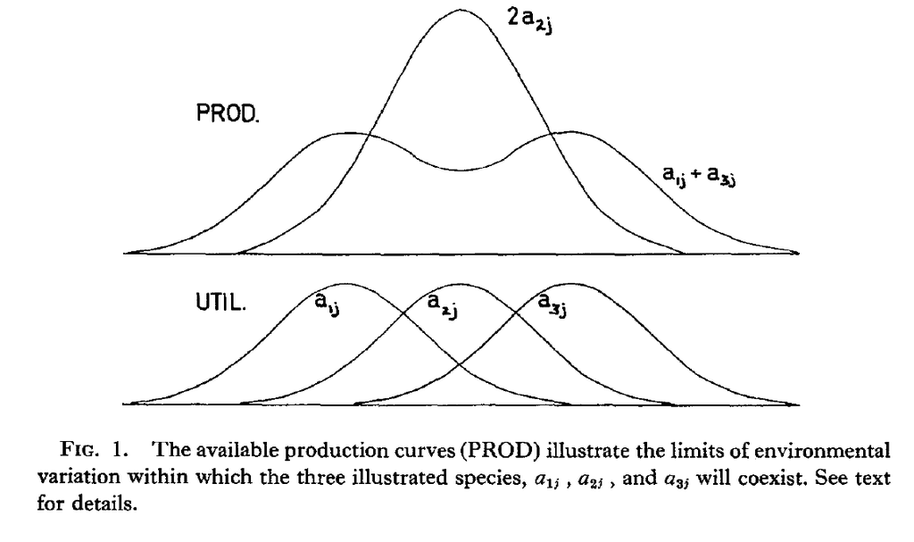

Match between the utility curves (bottom) and the resource availability (top) determines the coexistence beteen consumer species

## 1.1 Model

I apply a simple Lotka-Volterra model where and Carrying capacity (K) are estimated using the interaction data.

$$\frac{dN_{ilt}}{dt}=r_iN_{ilt}(1-\frac{N_{ilt}\sum_{j=1}^{n}\alpha_{ij}N_{jlt}}{K_{ilt}})$$
*Subscripts: i,j=species, l=elevation point, t=timepoint*

Expected equilibrium population sizes will be given by a system of simultaneous equations:
$$N_{ilt}^*\sum_{j=1}^{n}\alpha_{ij}N_{jlt}^*=K_{ilt}$$
i.e. The expected equilibrium population sizes depend on and carrying capacities, and can be estimated using empirical data.

# 2 **Dataset**

Sample of raw data: Each row is one observation of interaction between a pair of plant species and a hummingbird species.

```r
#The elevation values were put in six bins using the thresholds (1300,1500,1700,1900,2100,2300,2500)
kable(int.sum[sample(1:nrow(int.sum),10),])
```

|  | plant | month | year | elevation | bird | Y | corolla | abundance |
| --- | --- | --- | --- | --- | --- | --- | --- | --- |
| 873 | Pitcairnia sodiroi | 7 | 2013 | 5 | Violet-tailed Sylph | 4.5119236 | 48.17 | 1.551445 |
| 714 | Palicourea demissa | 4 | 2016 | 6 | Crowned Woodnymph | 1.0912054 | 19.79 | 4.582089 |
| 268 | Drymonia teuscheri | 7 | 2013 | 1 | Stripe-throated Hermit | 0.4480070 | 23.64 | 6.696324 |
| 51 | Besleria solanoides | 10 | 2013 | 6 | Booted Racket-tail | 0.2451808 | 16.23 | 8.157246 |
| 119 | Centropogon solanifolius | 5 | 2014 | 5 | Tawny-bellied Hermit | 1.3182723 | 51.48 | 2.275706 |
| 619 | Norantea anomala | 9 | 2013 | 2 | Booted Racket-tail | 0.4908090 | 10.00 | 8.149809 |
| 150 | Columnea ciliata | 1 | 2014 | 1 | Stripe-throated Hermit | 0.3570357 | 48.22 | 2.800841 |
| 835 | Palicourea lineata | 6 | 2015 | 6 | Gorgeted Sunangel | 0.5561758 | 16.44 | 7.191970 |
| 657 | Palicourea acetosoides | 2 | 2014 | 5 | Green-fronted Lancebill | 0.7602999 | 22.95 | 3.945811 |
| 200 | Columnea mastersonii | 9 | 2014 | 5 | Tawny-bellied Hermit | 1.3342748 | 43.39 | 3.747354 |

*Y=Freqency of interaction between a bird species and a plant species* *abundance=plant species abundance*

## 2.1 Utility Curves

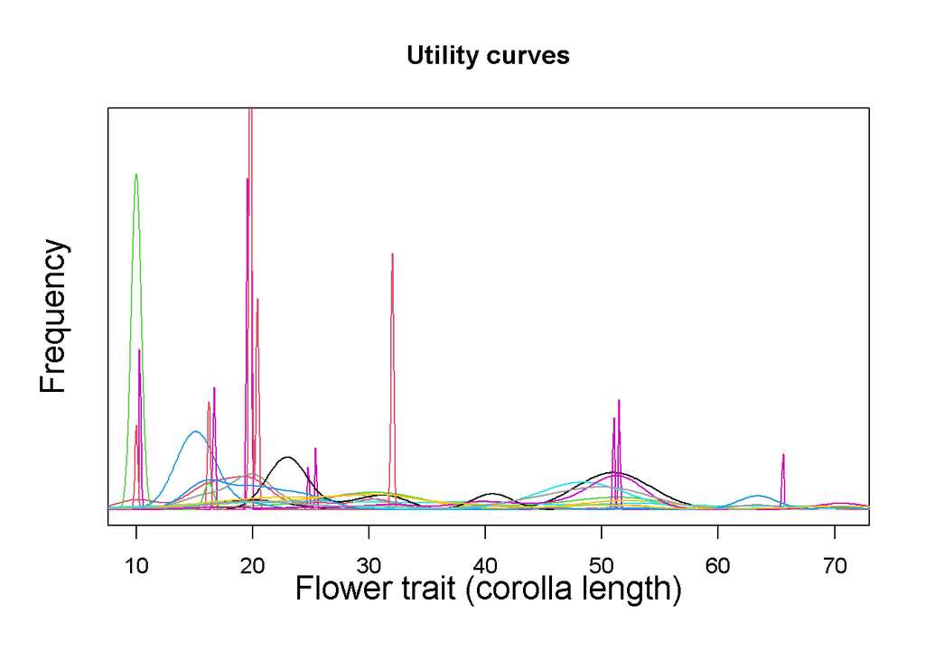

## 2.2 Carrying capacities

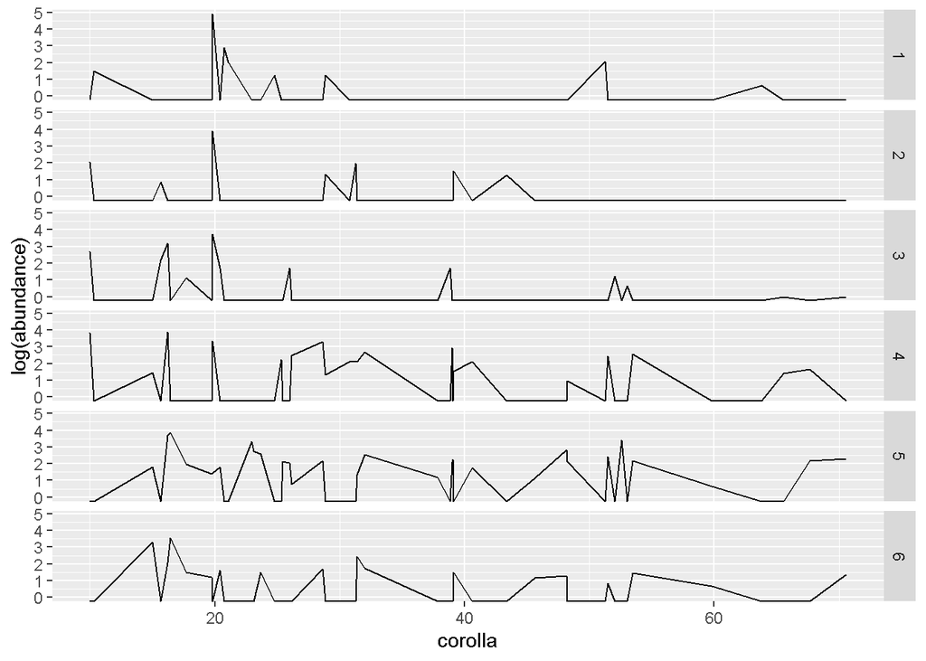

```r
sampledat<-int.sum%>%filter(year==2015)%>%select(corolla,month,elevation,abundance)%>%
            group_by(corolla,elevation)%>%summarise(abundance=sum(abundance))%>%ungroup()
sampledat<-sampledat%>%complete(corolla,elevation,fill=list(abundance=0))

ggplot(sampledat,aes(corolla,log(abundance)))+geom_line()+facet_grid(elevation~.)
```

# 3 **Hypothesis testing**

I used hierarchical structure of hypotheses that estimate the probabilities of occurance for each hummingbird species at a given location at a given time point

**Model 1: Elevation only**

1a: Probabilities generated from the frequencies of observations of each bird species on different elevations in training data are used to predict the occurances of species at every time-point and elevation in testing data.

1b:Wing area of Hummingbirds is shown to affect flight ability correlate negatively with elevation. (Altshuler et.al. 2004, Stiles et.al. 2005). In this model, I assume that the probability of occurance is only determined by the probability of recruitment at different elevations which is proportional to the wing-area of Hummingbird species.

**Model 2: Elevation + Resources**

Elevation may inform about the resource availability but resources vary over time at a given elevation as well. Probability of occurance for each hummingbird species is a function of elevation (which informs their ability to colonize at a given location independent of resources) and the amount of available resources. However, available resources can be estimated by two ways:

2a. I assume that the occurance probability is proportional to the total amount of resources available at the given elevation and time-point. Thus, same occurance probability applies for all the bird species at a given time-point and location.

2b. Here, I use carrying capacity to represent resource availability.Thus the probability varies for different bird species.

**Model 3: Elevation +Resources + Competition** Once species colonize at a given location, they are all assumed to compete with each other, given available resources and the resource use overlap between pairs. Previously described Lotka=Volterra is applied here. Expected equilibrium population sizes are linearly transformed into occurance probabilities.

Note: Even though it is a hierarchical structure, adding complexity to the model doesn’t necessarily improve the model performance. For example, if species happen to somehow avoid the impact competition, model 3 could underpredict presences and have a worse prediction than the previous models.

# 4 **Method**

# 5 **Results**

**Model 1**

Model 1a:Proportions of occurances of each Hummingbird species across different elevations were used as recruitment probabilities.

Model 1b: A linear relationship between wing area of birds and their ability to occupy elevations is used to predict recruitment probabilities.

Just by looking at the predictions of presences and absences,

```r
table(as.numeric(results$Model1a>0))
```

```
##
##   0   1
## 360 776
```

```r
table(as.numeric(results$Model1b.1>0))
```

```
##
##   0   1
## 337 799
```

```r
table(as.numeric(results$Model1b.2>0))
```

```
##
##   0   1
## 294 842
```

Where the observed data shows:

```r
table(as.numeric(results$Y>0))
```

```
##
##   0   1
## 889 247
```

*So, the elevation models heavily overpredict the presences. So, the sensitivity might be high but specificity might be low for these models.* This is not necessarily a big issue though. The raw data I used only have the presence data. I completed the dataset for the rest of the variable combinations (time-point, elevation and bird species) with absences. So, the dataset probably over-represents the absence data.

**Model 2** Does the total amount of resources at each sampling point predict the occurance for each bird speces?

```r
r1<-merge(testdat,abund1,all.x=TRUE)
auc_abun<-c()
for(i in 1:length(test.bird)){
  rdat<-r1[which(r1$bird==test.bird[i]),]
  auc_abun<-c(auc_abun,roc(rdat$Y,rdat$abundance)$auc)
}

kable(data.frame(bird=test.bird,AUC_abundance=auc_abun),caption="AUC values of prediction using total resource abundances at every time point")
```

AUC values of prediction using total resource abundances at every time point

| bird | AUC_abundance |
| --- | --- |
| Andean Emerald | 0.8725490 |
| Booted Racket-tail | 0.6849206 |
| Brown Inca | 0.7393162 |
| Buff-tailed Coronet | 0.7461874 |
| Collared Inca | 0.5726190 |
| Crowned Woodnymph | 0.4498208 |
| Fawn-breasted Brilliant | 0.7025641 |
| Gorgeted Sunangel | 0.5920455 |
| Green-fronted Lancebill | 0.6743590 |
| Purple-bibbed Whitetip | 0.6147541 |
| Sparkling Violetear | 0.6384615 |
| Speckled Hummingbird | 0.6875000 |
| Stripe-throated Hermit | 0.6242424 |
| Tawny-bellied Hermit | 0.7408293 |
| Violet-tailed Sylph | 0.7857143 |
| White-whiskered Hermit | 0.6426230 |

Not really!

```r
#Model2: Resource avaiability predicts the species presences

kdat.train<-kdat%>%filter(year>2014, bird%in%test.bird)
results<-merge(results,kdat.train,all.x=TRUE)
results<-results[order(results$bird,results$month,results$year,results$elevation),]

colnames(results)[9]<-"Model2"

#Combine model 1 with model 2

results$Model1a.2<-results$Model2
results$Model1a.2[which(results$Model1a==0)]<-0
results$Model1b1.2<-results$Model2
results$Model1b1.2[which(results$Model1b.1==0)]<-0
results$Model1b2.2<-results$Model2
results$Model1b2.2[which(results$Model1b.2==0)]<-0
```

**Model 3**

```r
#Model3a: Species occupancy is driven by both the resource availability and competition (apply L-V equations)
#Test data from 2015 and 2016

abd<-matrix(ncol=5)


for(i in 1:nrow(samples.test)){
  Klist<-kdat.train%>%filter(month==samples.test[i,1],year==samples.test[i,2],elevation==samples.test[i,3])%>%
          select(K)
  pops<-solve(alphamat,unlist(Klist))
  pops[pops<0]<-0
  pops<-pops+abs(min(pops))
  pops<-pops/max(pops)
  abd<-rbind(abd,cbind(as.matrix(samples.test[rep(i,length(pops)),]),test.bird,pops))
}

abd<-as.data.frame(abd)
abd<-abd[-1,]
abd[,1]<-as.numeric(abd[,1])
abd[,2]<-as.numeric(abd[,2])
abd[,3]<-as.numeric(abd[,3])
abd[,5]<-as.numeric(abd[,5])

colnames(abd)<-c("month","year","elevation","bird","pop")

results<-merge(results,abd,all.x=TRUE)
colnames(results)[ncol(results)]<-"Model3"
results<-results[order(results$bird,results$month,results$year,results$elevation),]
```

```r
#Model3a: Species occupancy is driven by elevation and LV equations.
#Test data from 2015 and 2015

eldat<-as.data.frame(cast(train.el,bird~elevation))
abd2<-matrix(ncol=5)

for(i in 1:nrow(samples.test)){
  el<-samples.test[i,3]
  begin.list<-eldat$bird[which(eldat[,(el+1)]!=0)]
  begin.list<-begin.list[order(begin.list)]
  ind<-match(begin.list,birdlist)
  alphamat1<-alphamat[ind,ind]
  Klist<-kdat.train%>%
          filter(month==samples.test[i,1],year==samples.test[i,2],elevation==el,bird%in%begin.list)%>%
           select(K)
  pops<-solve(alphamat1,unlist(Klist))
  pops<-pops+abs(min(pops))
  pops<-pops/max(pops)
  abd2<-rbind(abd2,cbind(as.matrix(samples.test[rep(i,length(begin.list)),]),begin.list,pops))
}

abd2<-as.data.frame(abd2)
abd2<-abd2[-1,]
abd2[,1]<-as.numeric(abd2[,1])
abd2[,2]<-as.numeric(abd2[,2])
abd2[,3]<-as.numeric(abd2[,3])
abd2[,5]<-as.numeric(abd2[,5])

colnames(abd2)<-c("month","year","elevation","bird","pop")
abd2<-as.data.frame(abd2%>%complete(bird,nesting(month,year,elevation),fill=list(pop=0)))


results<-merge(results,abd2,all.x=TRUE)
colnames(results)[ncol(results)]<-"Model13"
results<-results[order(results$bird,results$month,results$year,results$elevation),]


kable(head(results),caption="Sample of predictions under different models")
```

Sample of predictions under different models

|  | bird | elevation | month | year | Y | Model1a | Model1b.1 | Model1b.2 | Model2 | Model1a.2 | Model1b1.2 | Model1b2.2 | Model3 | Model13 |
| --- | --- | --- | --- | --- | --- | --- | --- | --- | --- | --- | --- | --- | --- | --- |
| 1 | Andean Emerald | 1 | 1 | 2015 | 0 | 1 | 0.00 | 0.00 | 0 | 0 | 0 | 0 | 0.0000000 | 0.4118287 |
| 13 | Andean Emerald | 2 | 1 | 2015 | 0 | 0 | 0.00 | 0.08 | 0 | 0 | 0 | 0 | 0.0000000 | 0.0000000 |
| 24 | Andean Emerald | 3 | 1 | 2015 | 0 | 0 | 0.06 | 0.34 | 0 | 0 | 0 | 0 | 0.1527896 | 0.0000000 |
| 34 | Andean Emerald | 4 | 1 | 2015 | 0 | 0 | 0.18 | 0.52 | 0 | 0 | 0 | 0 | 0.1527896 | 0.0000000 |
| 46 | Andean Emerald | 5 | 1 | 2015 | 0 | 0 | 0.37 | 0.06 | 0 | 0 | 0 | 0 | 0.0111487 | 0.0000000 |
| 59 | Andean Emerald | 6 | 1 | 2015 | 0 | 0 | 0.25 | 0.01 | 0 | 0 | 0 | 0 | 0.0000000 | 0.0000000 |

Descriptions of all the models I employed:

```r
txt<-c("Elevation freq.","Wing size cont.","wing size disc.","Carrying capacity",
       "Elevation freq + Carrying Capacity","wing size cont.+ Carrying Capacity",
       "wing size disc. + Carrying Capacity","Lotka-Volterra model","Elevation freq.+LV model")
txt2<-c("Elevation","Elevation","Elevation","Resources","Elevation + Resources","Elevation + Resources","Elevation + Resources","Competition","Competition")
Model_info<-data.frame(colnames(results[6:14]),Description=txt2)
kable(Model_info)
```

| colnames.results.6.14.. | Description |
| --- | --- |
| Model1a | Elevation |
| Model1b.1 | Elevation |
| Model1b.2 | Elevation |
| Model2 | Resources |
| Model1a.2 | Elevation + Resources |
| Model1b1.2 | Elevation + Resources |
| Model1b2.2 | Elevation + Resources |
| Model3 | Competition |
| Model13 | Competition |

Now, to compare model predictions, I use AUC values.

```r
AUC_table<-data.frame(bird=test.bird,culmen=birdbill$culmen,role=birdforage$role)
no_models<-ncol(results)-5

for(j in 1:no_models){
    aucdat<-c()
  for(i in 1:length(test.bird)){
    res<-results[which(results$bird==test.bird[i]),c(5,j+5)]
    aucdat<-c(aucdat,roc(res[,1],res[,2])$auc)
  }
    name<-colnames(results)[5+j]
    AUC_table[name]<-aucdat
}

kable(data.frame(AUC_table[],Total_data=bird.obs$Y))
```

| bird | culmen | role | Model1a | Model1b.1 | Model1b.2 | Model2 | Model1a.2 | Model1b1.2 | Model1b2.2 | Model3 | Model13 | Total_data |
| --- | --- | --- | --- | --- | --- | --- | --- | --- | --- | --- | --- | --- |
| Andean Emerald | 25.23 | Territorial | 0.7598039 | 0.8529412 | 0.6789216 | 1.0000000 | 0.8333333 | 0.5000000 | 1.0000000 | 1.0000000 | 0.8186275 | 22 |
| Booted Racket-tail | 14.81 | Generalist | 0.6896825 | 0.5436508 | 0.6269841 | 0.9722222 | 0.9722222 | 0.8750000 | 0.8888889 | 0.9955357 | 0.9575397 | 310 |
| Brown Inca | 36.83 | Trapliner | 0.8333333 | 0.5760684 | 0.8397436 | 0.9230769 | 0.9230769 | 0.8461538 | 0.8846154 | 0.8789869 | 0.8901709 | 258 |
| Buff-tailed Coronet | 19.92 | Territorial | 0.7962963 | 0.8458606 | 0.5032680 | 0.7647059 | 0.7647059 | 0.7352941 | 0.7352941 | 0.8335294 | 0.7832244 | 123 |
| Collared Inca | 36.03 | Trapliner | 0.8154762 | 0.8416667 | 0.4714286 | 0.8000000 | 0.8000000 | 0.8000000 | 0.8000000 | 0.7423077 | 0.7869048 | 108 |
| Crowned Woodnymph | NA | NA | 0.8933692 | 0.8924731 | 0.7508961 | 0.8888889 | 0.8333333 | 0.5555556 | 0.7777778 | 0.9004237 | 0.8333333 | 72 |
| Fawn-breasted Brilliant | 24.55 | Territorial | 0.8974359 | 0.6230769 | 0.9012821 | 0.5833333 | 0.5833333 | 0.5833333 | 0.5833333 | 0.6112903 | 0.7346154 | 38 |
| Gorgeted Sunangel | 17.78 | Territorial | 0.8704545 | 0.7875000 | 0.5585227 | 0.9687500 | 0.9687500 | 0.9687500 | 0.8750000 | 0.9264706 | 0.9795455 | 140 |
| Green-fronted Lancebill | 34.43 | Trapliner | 0.8820513 | 0.6935897 | 0.8230769 | 1.0000000 | 1.0000000 | 1.0000000 | 1.0000000 | 1.0000000 | 0.9948718 | 54 |
| Purple-bibbed Whitetip | 21.60 | Generalist | 0.4704918 | 0.6000000 | 0.7762295 | 0.9500000 | 0.8000000 | 0.8500000 | 0.9500000 | 0.9412281 | 0.6860656 | 28 |
| Sparkling Violetear | 28.29 | Territorial | 0.8423077 | 0.5141026 | 0.8307692 | 0.9166667 | 0.9166667 | 0.8333333 | 0.9166667 | 0.8975410 | 0.9717949 | 64 |
| Speckled Hummingbird | 17.06 | Generalist | 0.7232143 | 0.7433036 | 0.8895089 | 0.7142857 | 0.7142857 | 0.7142857 | 0.7142857 | 0.7297619 | 0.9520089 | 87 |
| Stripe-throated Hermit | 24.48 | Generalist | 0.9568182 | 0.9250000 | 0.8424242 | 1.0000000 | 1.0000000 | 0.5000000 | 0.6363636 | 0.6558442 | 0.7424242 | 225 |
| Tawny-bellied Hermit | 44.18 | Trapliner | 0.5980861 | 0.5861244 | 0.7009569 | 0.7272727 | 0.7272727 | 0.6969697 | 0.7121212 | 0.6126126 | 0.6989633 | 410 |
| Violet-tailed Sylph | 18.87 | Territorial | 0.8186508 | 0.7174603 | 0.7789683 | 0.9305556 | 0.9305556 | 0.8611111 | 0.9166667 | 0.8978495 | 0.9496032 | 441 |
| White-whiskered Hermit | 45.40 | Trapliner | 0.9459016 | 0.8934426 | 0.8704918 | 0.8500000 | 0.8500000 | 0.5000000 | 0.5500000 | 0.8516949 | 0.7836066 | 159 |

```r
best.auc<-apply(AUC_table[,-c(1:3)],1,max)
best.model<-apply(AUC_table[,-c(1:3)],1,which.max)


Winners<-data.frame(AUC_table[,1:3],Total_data=bird.obs$Y,Best_model=Model_info[best.model,2],AUC=best.auc)

Winners<-Winners[order(Winners$culmen,Winners$role),]


kable(Winners)
```

|  | bird | culmen | role | Total_data | Best_model | AUC |
| --- | --- | --- | --- | --- | --- | --- |
| 2 | Booted Racket-tail | 14.81 | Generalist | 310 | Competition | 0.9955357 |
| 12 | Speckled Hummingbird | 17.06 | Generalist | 87 | Competition | 0.9520089 |
| 8 | Gorgeted Sunangel | 17.78 | Territorial | 140 | Competition | 0.9795455 |
| 15 | Violet-tailed Sylph | 18.87 | Territorial | 441 | Competition | 0.9496032 |
| 4 | Buff-tailed Coronet | 19.92 | Territorial | 123 | Elevation | 0.8458606 |
| 10 | Purple-bibbed Whitetip | 21.60 | Generalist | 28 | Resources | 0.9500000 |
| 13 | Stripe-throated Hermit | 24.48 | Generalist | 225 | Resources | 1.0000000 |
| 7 | Fawn-breasted Brilliant | 24.55 | Territorial | 38 | Elevation | 0.9012821 |
| 1 | Andean Emerald | 25.23 | Territorial | 22 | Resources | 1.0000000 |
| 11 | Sparkling Violetear | 28.29 | Territorial | 64 | Competition | 0.9717949 |
| 9 | Green-fronted Lancebill | 34.43 | Trapliner | 54 | Resources | 1.0000000 |
| 5 | Collared Inca | 36.03 | Trapliner | 108 | Elevation | 0.8416667 |
| 3 | Brown Inca | 36.83 | Trapliner | 258 | Resources | 0.9230769 |
| 14 | Tawny-bellied Hermit | 44.18 | Trapliner | 410 | Resources | 0.7272727 |
| 16 | White-whiskered Hermit | 45.40 | Trapliner | 159 | Elevation | 0.9459016 |
| 6 | Crowned Woodnymph | NA | NA | 72 | Competition | 0.9004237 |

Do the other metrics agree with this?

Other metrics: Correct classification rate, Sensitivity, Specificity, Kappa, and True Skill statistics

**First try: I use a common optimal threshold for every model: 0.5**

Correct classification rates

|  | Model1a | Model1b.1 | Model1b.2 | Model2 | Model1a.2 | Model1b1.2 | Model1b2.2 | Model3 | Model13 |
| --- | --- | --- | --- | --- | --- | --- | --- | --- | --- |
| Andean Emerald | 0.8450704 | 0.9577465 | 0.9154930 | 1.0000000 | 0.9859155 | 0.9577465 | 1.0000000 | 0.9850746 | 0.9859155 |
| Booted Racket-tail | 0.4929577 | 0.4929577 | 0.4929577 | 0.9295775 | 0.9295775 | 0.8309859 | 0.8591549 | 0.9104478 | 0.9295775 |
| Brown Inca | 0.7464789 | 0.4929577 | 0.6619718 | 0.7605634 | 0.7605634 | 0.7323944 | 0.7464789 | 0.9104478 | 0.9014085 |
| Buff-tailed Coronet | 0.7605634 | 0.7605634 | 0.7183099 | 0.8591549 | 0.8591549 | 0.8450704 | 0.8450704 | 0.7462687 | 0.7887324 |
| Collared Inca | 0.8309859 | 0.8028169 | 0.7323944 | 0.8309859 | 0.8309859 | 0.8309859 | 0.8309859 | 0.8507463 | 0.8732394 |
| Crowned Woodnymph | 0.9295775 | 0.8732394 | 0.8028169 | 0.9577465 | 0.9436620 | 0.8873239 | 0.9295775 | 0.8955224 | 0.9154930 |
| Fawn-breasted Brilliant | 0.8591549 | 0.9014085 | 0.8873239 | 0.9295775 | 0.9295775 | 0.9295775 | 0.9295775 | 0.8955224 | 0.9154930 |
| Gorgeted Sunangel | 0.8169014 | 0.7746479 | 0.7323944 | 0.8732394 | 0.8732394 | 0.8732394 | 0.8591549 | 0.8955224 | 0.9718310 |
| Green-fronted Lancebill | 0.9154930 | 0.8028169 | 0.8732394 | 0.9718310 | 0.9718310 | 0.9718310 | 0.9718310 | 0.9104478 | 0.9859155 |
| Purple-bibbed Whitetip | 0.7464789 | 0.8450704 | 0.8591549 | 0.9859155 | 0.9436620 | 0.9577465 | 0.9859155 | 0.8656716 | 0.8591549 |
| Sparkling Violetear | 0.8309859 | 0.9014085 | 0.9295775 | 0.9859155 | 0.9859155 | 0.9718310 | 0.9859155 | 0.9253731 | 0.9154930 |
| Speckled Hummingbird | 0.7464789 | 0.7464789 | 0.9577465 | 0.9295775 | 0.9295775 | 0.9295775 | 0.9295775 | 0.9104478 | 0.9154930 |
| Stripe-throated Hermit | 0.9295775 | 0.8450704 | 0.8028169 | 0.9295775 | 0.9295775 | 0.8450704 | 0.8450704 | 0.8955224 | 0.8873239 |
| Tawny-bellied Hermit | 0.5352113 | 0.4647887 | 0.5211268 | 0.5774648 | 0.5774648 | 0.5774648 | 0.5774648 | 0.6119403 | 0.6901408 |
| Violet-tailed Sylph | 0.4929577 | 0.4929577 | 0.5774648 | 0.7323944 | 0.7323944 | 0.6619718 | 0.7183099 | 0.8955224 | 0.8873239 |
| White-whiskered Hermit | 0.9154930 | 0.8591549 | 0.7464789 | 0.9014085 | 0.9014085 | 0.8591549 | 0.8591549 | 0.9701493 | 0.8450704 |

Sensitivity

|  | Model1a | Model1b.1 | Model1b.2 | Model2 | Model1a.2 | Model1b1.2 | Model1b2.2 | Model3 | Model13 |
| --- | --- | --- | --- | --- | --- | --- | --- | --- | --- |
| Andean Emerald | 0.6666667 | 0.0000000 | 0.0000000 | 1.0000000 | 0.6666667 | 0.0000000 | 1.0000000 | 0.6666667 | 0.6666667 |
| Booted Racket-tail | 0.0000000 | 0.0277778 | 0.0555556 | 0.8611111 | 0.8611111 | 0.6666667 | 0.7222222 | 0.8285714 | 0.9166667 |
| Brown Inca | 0.3846154 | 0.0384615 | 0.1153846 | 0.3461538 | 0.3461538 | 0.2692308 | 0.3076923 | 0.7692308 | 0.7692308 |
| Buff-tailed Coronet | 0.0000000 | 0.0000000 | 0.0588235 | 0.4117647 | 0.4117647 | 0.3529412 | 0.3529412 | 0.0000000 | 0.4705882 |
| Collared Inca | 0.5333333 | 0.0666667 | 0.0666667 | 0.2000000 | 0.2000000 | 0.2000000 | 0.2000000 | 0.3333333 | 0.5333333 |
| Crowned Woodnymph | 0.8888889 | 0.0000000 | 0.0000000 | 0.6666667 | 0.5555556 | 0.1111111 | 0.4444444 | 0.1250000 | 0.5555556 |
| Fawn-breasted Brilliant | 0.6666667 | 0.0000000 | 0.0000000 | 0.1666667 | 0.1666667 | 0.1666667 | 0.1666667 | 0.2000000 | 0.1666667 |
| Gorgeted Sunangel | 0.5000000 | 0.0000000 | 0.0000000 | 0.4375000 | 0.4375000 | 0.4375000 | 0.3750000 | 0.5625000 | 0.8750000 |
| Green-fronted Lancebill | 0.0000000 | 0.0000000 | 0.1666667 | 0.6666667 | 0.6666667 | 0.6666667 | 0.6666667 | 0.0000000 | 1.0000000 |
| Purple-bibbed Whitetip | 0.2000000 | 0.0000000 | 0.2000000 | 0.9000000 | 0.6000000 | 0.7000000 | 0.9000000 | 0.1000000 | 0.5000000 |
| Sparkling Violetear | 0.5000000 | 0.0000000 | 0.5000000 | 0.8333333 | 0.8333333 | 0.6666667 | 0.8333333 | 0.1666667 | 0.8333333 |
| Speckled Hummingbird | 0.1428571 | 0.1428571 | 0.5714286 | 0.2857143 | 0.2857143 | 0.2857143 | 0.2857143 | 0.1428571 | 0.5714286 |
| Stripe-throated Hermit | 0.8181818 | 0.0000000 | 0.0000000 | 0.5454545 | 0.5454545 | 0.0000000 | 0.0000000 | 0.3636364 | 0.4545455 |
| Tawny-bellied Hermit | 0.0000000 | 0.1212121 | 0.0000000 | 0.0909091 | 0.0909091 | 0.0909091 | 0.0909091 | 0.1333333 | 0.5454545 |
| Violet-tailed Sylph | 0.0000000 | 0.0000000 | 0.1944444 | 0.4722222 | 0.4722222 | 0.3333333 | 0.4444444 | 0.8055556 | 0.7777778 |
| White-whiskered Hermit | 0.8000000 | 0.0000000 | 0.0000000 | 0.3000000 | 0.3000000 | 0.0000000 | 0.0000000 | 0.7500000 | 0.6000000 |

Specificity

|  | Model1a | Model1b.1 | Model1b.2 | Model2 | Model1a.2 | Model1b1.2 | Model1b2.2 | Model3 | Model13 |
| --- | --- | --- | --- | --- | --- | --- | --- | --- | --- |
| Andean Emerald | 0.8529412 | 1.0000000 | 0.9558824 | 1 | 1 | 1 | 1 | 1.0000000 | 1.0000000 |
| Booted Racket-tail | 1.0000000 | 0.9714286 | 0.9428571 | 1 | 1 | 1 | 1 | 1.0000000 | 0.9428571 |
| Brown Inca | 0.9555556 | 0.7555556 | 0.9777778 | 1 | 1 | 1 | 1 | 1.0000000 | 0.9777778 |
| Buff-tailed Coronet | 1.0000000 | 1.0000000 | 0.9259259 | 1 | 1 | 1 | 1 | 1.0000000 | 0.8888889 |
| Collared Inca | 0.9107143 | 1.0000000 | 0.9107143 | 1 | 1 | 1 | 1 | 1.0000000 | 0.9642857 |
| Crowned Woodnymph | 0.9354839 | 1.0000000 | 0.9193548 | 1 | 1 | 1 | 1 | 1.0000000 | 0.9677419 |
| Fawn-breasted Brilliant | 0.8769231 | 0.9846154 | 0.9692308 | 1 | 1 | 1 | 1 | 0.9516129 | 0.9846154 |
| Gorgeted Sunangel | 0.9090909 | 1.0000000 | 0.9454545 | 1 | 1 | 1 | 1 | 1.0000000 | 1.0000000 |
| Green-fronted Lancebill | 1.0000000 | 0.8769231 | 0.9384615 | 1 | 1 | 1 | 1 | 1.0000000 | 0.9846154 |
| Purple-bibbed Whitetip | 0.8360656 | 0.9836066 | 0.9672131 | 1 | 1 | 1 | 1 | 1.0000000 | 0.9180328 |
| Sparkling Violetear | 0.8615385 | 0.9846154 | 0.9692308 | 1 | 1 | 1 | 1 | 1.0000000 | 0.9230769 |
| Speckled Hummingbird | 0.8125000 | 0.8125000 | 1.0000000 | 1 | 1 | 1 | 1 | 1.0000000 | 0.9531250 |
| Stripe-throated Hermit | 0.9500000 | 1.0000000 | 0.9500000 | 1 | 1 | 1 | 1 | 1.0000000 | 0.9666667 |
| Tawny-bellied Hermit | 1.0000000 | 0.7631579 | 0.9736842 | 1 | 1 | 1 | 1 | 1.0000000 | 0.8157895 |
| Violet-tailed Sylph | 1.0000000 | 1.0000000 | 0.9714286 | 1 | 1 | 1 | 1 | 1.0000000 | 1.0000000 |
| White-whiskered Hermit | 0.9344262 | 1.0000000 | 0.8688525 | 1 | 1 | 1 | 1 | 1.0000000 | 0.8852459 |

kappa statistic

|  | Model1a | Model1b.1 | Model1b.2 | Model2 | Model1a.2 | Model1b1.2 | Model1b2.2 | Model3 | Model13 |
| --- | --- | --- | --- | --- | --- | --- | --- | --- | --- |
| Andean Emerald | 33.293401 | Inf | 493.02660 | 21.751174 | 34.198565 | Inf | 21.751174 | 32.200508 | 34.198565 |
| Booted Racket-tail | Inf | 2416.000827 | 1142.00175 | 1.324161 | 1.324161 | 2.109849 | 1.836860 | 1.380951 | 1.238314 |
| Brown Inca | 6.890214 | 9.592434 | 27.95140 | 7.362915 | 7.362915 | 9.744123 | 8.412869 | 2.258122 | 2.444578 |
| Buff-tailed Coronet | Inf | Inf | 238.11681 | 9.434329 | 9.434329 | 11.230543 | 11.230543 | Inf | 8.854355 |
| Collared Inca | 8.259711 | 70.891996 | 177.01199 | 23.328298 | 23.328298 | 23.328298 | 23.328298 | 12.825414 | 8.024446 |
| Crowned Woodnymph | 7.047543 | Inf | 85.01471 | 10.599502 | 13.164942 | 70.800963 | 16.921953 | 66.773946 | 13.196915 |
| Fawn-breasted Brilliant | 16.194345 | 747.805164 | 363.52700 | 70.687500 | 70.687500 | 70.687500 | 70.687500 | 80.030194 | 75.590716 |
| Gorgeted Sunangel | 8.460249 | Inf | 74.76966 | 9.380481 | 9.380481 | 9.380481 | 11.183727 | 6.474043 | 3.645503 |
| Green-fronted Lancebill | Inf | 76.920481 | 99.46484 | 16.481707 | 16.481707 | 16.481707 | 16.481707 | Inf | 9.882079 |
| Purple-bibbed Whitetip | 143.142331 | 421.071831 | 39.51754 | 6.302184 | 10.727593 | 8.864414 | 6.302184 | 66.825153 | 13.756091 |
| Sparkling Violetear | 24.401971 | 747.805164 | 22.85171 | 12.637500 | 12.637500 | 16.481707 | 12.637500 | 66.688776 | 12.123069 |
| Speckled Hummingbird | 159.495013 | 159.495013 | 16.66755 | 34.963312 | 34.963312 | 34.963312 | 34.963312 | 66.737418 | 16.669161 |
| Stripe-throated Hermit | 6.320786 | Inf | 118.64277 | 10.834720 | 10.834720 | Inf | Inf | 16.092144 | 13.605173 |
| Tawny-bellied Hermit | Inf | 13.252559 | 79.48698 | 23.561257 | 23.561257 | 23.561257 | 23.561257 | 16.585738 | 3.965478 |
| Violet-tailed Sylph | Inf | Inf | 11.08727 | 3.553434 | 3.553434 | 5.492424 | 3.852949 | 1.414034 | 1.605923 |
| White-whiskered Hermit | 7.260365 | Inf | 43.31215 | 23.118762 | 23.118762 | Inf | Inf | 9.783854 | 10.911616 |

True Skill statistic

|  | Model1a | Model1b.1 | Model1b.2 | Model2 | Model1a.2 | Model1b1.2 | Model1b2.2 | Model3 | Model13 |
| --- | --- | --- | --- | --- | --- | --- | --- | --- | --- |
| Andean Emerald | 0.5196078 | 0.0000000 | -0.0441176 | 1.0000000 | 0.6666667 | 0.0000000 | 1.0000000 | 0.6666667 | 0.6666667 |
| Booted Racket-tail | 0.0000000 | -0.0007937 | -0.0015873 | 0.8611111 | 0.8611111 | 0.6666667 | 0.7222222 | 0.8285714 | 0.8595238 |
| Brown Inca | 0.3401709 | -0.2059829 | 0.0931624 | 0.3461538 | 0.3461538 | 0.2692308 | 0.3076923 | 0.7692308 | 0.7470085 |
| Buff-tailed Coronet | 0.0000000 | 0.0000000 | -0.0152505 | 0.4117647 | 0.4117647 | 0.3529412 | 0.3529412 | 0.0000000 | 0.3594771 |
| Collared Inca | 0.4440476 | 0.0666667 | -0.0226190 | 0.2000000 | 0.2000000 | 0.2000000 | 0.2000000 | 0.3333333 | 0.4976190 |
| Crowned Woodnymph | 0.8243728 | 0.0000000 | -0.0806452 | 0.6666667 | 0.5555556 | 0.1111111 | 0.4444444 | 0.1250000 | 0.5232975 |
| Fawn-breasted Brilliant | 0.5435897 | -0.0153846 | -0.0307692 | 0.1666667 | 0.1666667 | 0.1666667 | 0.1666667 | 0.1516129 | 0.1512821 |
| Gorgeted Sunangel | 0.4090909 | 0.0000000 | -0.0545455 | 0.4375000 | 0.4375000 | 0.4375000 | 0.3750000 | 0.5625000 | 0.8750000 |
| Green-fronted Lancebill | 0.0000000 | -0.1230769 | 0.1051282 | 0.6666667 | 0.6666667 | 0.6666667 | 0.6666667 | 0.0000000 | 0.9846154 |
| Purple-bibbed Whitetip | 0.0360656 | -0.0163934 | 0.1672131 | 0.9000000 | 0.6000000 | 0.7000000 | 0.9000000 | 0.1000000 | 0.4180328 |
| Sparkling Violetear | 0.3615385 | -0.0153846 | 0.4692308 | 0.8333333 | 0.8333333 | 0.6666667 | 0.8333333 | 0.1666667 | 0.7564103 |
| Speckled Hummingbird | -0.0446429 | -0.0446429 | 0.5714286 | 0.2857143 | 0.2857143 | 0.2857143 | 0.2857143 | 0.1428571 | 0.5245536 |
| Stripe-throated Hermit | 0.7681818 | 0.0000000 | -0.0500000 | 0.5454545 | 0.5454545 | 0.0000000 | 0.0000000 | 0.3636364 | 0.4212121 |
| Tawny-bellied Hermit | 0.0000000 | -0.1156300 | -0.0263158 | 0.0909091 | 0.0909091 | 0.0909091 | 0.0909091 | 0.1333333 | 0.3612440 |
| Violet-tailed Sylph | 0.0000000 | 0.0000000 | 0.1658730 | 0.4722222 | 0.4722222 | 0.3333333 | 0.4444444 | 0.8055556 | 0.7777778 |
| White-whiskered Hermit | 0.7344262 | 0.0000000 | -0.1311475 | 0.3000000 | 0.3000000 | 0.0000000 | 0.0000000 | 0.7500000 | 0.4852459 |

|  | bird | culmen | role | Total_data | AUC_winners | pCC_winners | sens_winners | Spec_winners | Kappa_winners | TSS_winners |
| --- | --- | --- | --- | --- | --- | --- | --- | --- | --- | --- |
| 2 | Booted Racket-tail | 14.81 | Generalist | 310 | Competition | Resources | Competition | Elevation | Elevation | Resources |
| 12 | Speckled Hummingbird | 17.06 | Generalist | 87 | Competition | Elevation | Elevation | Elevation | Elevation | Elevation |
| 8 | Gorgeted Sunangel | 17.78 | Territorial | 140 | Competition | Competition | Competition | Elevation | Elevation | Competition |
| 15 | Violet-tailed Sylph | 18.87 | Territorial | 441 | Competition | Competition | Competition | Elevation | Elevation | Competition |
| 4 | Buff-tailed Coronet | 19.92 | Territorial | 123 | Elevation | Resources | Competition | Elevation | Elevation | Resources |
| 10 | Purple-bibbed Whitetip | 21.60 | Generalist | 28 | Resources | Resources | Resources | Resources | Elevation | Resources |
| 13 | Stripe-throated Hermit | 24.48 | Generalist | 225 | Resources | Elevation | Elevation | Elevation | Elevation | Elevation |
| 7 | Fawn-breasted Brilliant | 24.55 | Territorial | 38 | Elevation | Resources | Elevation | Resources | Elevation | Elevation |
| 1 | Andean Emerald | 25.23 | Territorial | 22 | Resources | Resources | Resources | Elevation | Elevation | Resources |
| 11 | Sparkling Violetear | 28.29 | Territorial | 64 | Competition | Resources | Resources | Resources | Elevation | Resources |
| 9 | Green-fronted Lancebill | 34.43 | Trapliner | 54 | Resources | Competition | Competition | Elevation | Elevation | Competition |
| 5 | Collared Inca | 36.03 | Trapliner | 108 | Elevation | Competition | Elevation | Elevation | Elevation | Competition |
| 3 | Brown Inca | 36.83 | Trapliner | 258 | Resources | Competition | Competition | Resources | Elevation | Competition |
| 14 | Tawny-bellied Hermit | 44.18 | Trapliner | 410 | Resources | Competition | Competition | Elevation | Elevation | Competition |
| 16 | White-whiskered Hermit | 45.40 | Trapliner | 159 | Elevation | Competition | Elevation | Elevation | Elevation | Competition |
| 6 | Crowned Woodnymph | NA | NA | 72 | Competition | Resources | Elevation | Elevation | Elevation | Elevation |

Second try: I use separate optimal thresholds for each models. Optimal threshold is chosen to maximize the sum of sensitivity and specificity.

|  | bird | culmen | role | Total_data | AUC_winners | pCC_winners | sens_winners | Spec_winners | Kappa_winners | TSS_winners |
| --- | --- | --- | --- | --- | --- | --- | --- | --- | --- | --- |
| 2 | Booted Racket-tail | 14.81 | Generalist | 310 | Competition | Competition | Competition | Resources | Elevation | Competition |
| 12 | Speckled Hummingbird | 17.06 | Generalist | 87 | Competition | Resources | Elevation | Resources | Resources | Competition |
| 8 | Gorgeted Sunangel | 17.78 | Territorial | 140 | Competition | Resources | Elevation | Resources | Elevation | Resources |
| 15 | Violet-tailed Sylph | 18.87 | Territorial | 441 | Competition | Resources | Resources | Resources | Elevation | Resources |
| 4 | Buff-tailed Coronet | 19.92 | Territorial | 123 | Elevation | Resources | Elevation | Resources | Elevation | Elevation |
| 10 | Purple-bibbed Whitetip | 21.60 | Generalist | 28 | Resources | Resources | Resources | Resources | Elevation | Resources |
| 13 | Stripe-throated Hermit | 24.48 | Generalist | 225 | Resources | Resources | Resources | Resources | Elevation + Resources | Resources |
| 7 | Fawn-breasted Brilliant | 24.55 | Territorial | 38 | Elevation | Resources | Elevation | Resources | Competition | Elevation |
| 1 | Andean Emerald | 25.23 | Territorial | 22 | Resources | Resources | Resources | Resources | Elevation + Resources | Resources |
| 11 | Sparkling Violetear | 28.29 | Territorial | 64 | Competition | Resources | Elevation | Resources | Elevation | Resources |
| 9 | Green-fronted Lancebill | 34.43 | Trapliner | 54 | Resources | Resources | Elevation | Resources | Elevation | Resources |
| 5 | Collared Inca | 36.03 | Trapliner | 108 | Elevation | Resources | Elevation | Resources | Elevation | Resources |
| 3 | Brown Inca | 36.83 | Trapliner | 258 | Resources | Resources | Elevation | Resources | Elevation | Resources |
| 14 | Tawny-bellied Hermit | 44.18 | Trapliner | 410 | Resources | Resources | Elevation | Resources | Elevation | Resources |
| 16 | White-whiskered Hermit | 45.40 | Trapliner | 159 | Elevation | Resources | Elevation | Resources | Elevation + Resources | Elevation |
| 6 | Crowned Woodnymph | NA | NA | 72 | Competition | Resources | Elevation | Resources | Elevation + Resources | Elevation |

Raw results with second optimal threshold

```r
kable(pCC.dat, caption="Correct classification rates")
```

Correct classification rates

|  | Model1a | Model1b.1 | Model1b.2 | Model2 | Model1a.2 | Model1b1.2 | Model1b2.2 | Model3 | Model13 |
| --- | --- | --- | --- | --- | --- | --- | --- | --- | --- |
| Andean Emerald | 0.8450704 | 0.4225352 | 0.6338028 | 1.0000000 | 0.9859155 | 0.9577465 | 1.0000000 | 0.5671642 | 0.9859155 |
| Booted Racket-tail | 0.6056338 | 0.4788732 | 0.5915493 | 0.9718310 | 0.9718310 | 0.8732394 | 0.8873239 | 0.9850746 | 0.9154930 |
| Brown Inca | 0.7887324 | 0.5915493 | 0.8028169 | 0.9436620 | 0.9436620 | 0.8873239 | 0.9154930 | 0.9104478 | 0.8450704 |
| Buff-tailed Coronet | 0.7887324 | 0.6760563 | 0.5211268 | 0.8873239 | 0.8873239 | 0.8732394 | 0.8732394 | 0.8656716 | 0.7746479 |
| Collared Inca | 0.7605634 | 0.6619718 | 0.4788732 | 0.9154930 | 0.9154930 | 0.9154930 | 0.9154930 | 0.8805970 | 0.8028169 |
| Crowned Woodnymph | 0.9295775 | 0.3098592 | 0.4225352 | 0.9718310 | 0.9577465 | 0.8873239 | 0.9436620 | 0.9552239 | 0.9154930 |
| Fawn-breasted Brilliant | 0.8591549 | 0.4929577 | 0.7605634 | 0.9295775 | 0.9295775 | 0.9295775 | 0.9295775 | 0.8059701 | 0.9295775 |
| Gorgeted Sunangel | 0.8028169 | 0.6619718 | 0.5352113 | 0.9859155 | 0.9859155 | 0.9859155 | 0.9436620 | 0.9253731 | 0.9577465 |
| Green-fronted Lancebill | 0.4084507 | 0.6056338 | 0.6760563 | 1.0000000 | 1.0000000 | 1.0000000 | 1.0000000 | 1.0000000 | 0.9436620 |
| Purple-bibbed Whitetip | 0.5633803 | 0.4788732 | 0.6901408 | 0.9859155 | 0.9436620 | 0.9577465 | 0.9859155 | 0.9850746 | 0.8309859 |
| Sparkling Violetear | 0.6197183 | 0.4788732 | 0.7042254 | 0.9859155 | 0.9859155 | 0.9718310 | 0.9859155 | 0.9701493 | 0.8873239 |
| Speckled Hummingbird | 0.6760563 | 0.6760563 | 0.6338028 | 0.9436620 | 0.9436620 | 0.9436620 | 0.9436620 | 0.9402985 | 0.9295775 |
| Stripe-throated Hermit | 0.9295775 | 0.3098592 | 0.5352113 | 1.0000000 | 1.0000000 | 0.8450704 | 0.8873239 | 0.8358209 | 0.8732394 |
| Tawny-bellied Hermit | 0.5070423 | 0.6338028 | 0.6619718 | 0.7464789 | 0.7464789 | 0.7183099 | 0.7323944 | 0.5970149 | 0.6478873 |
| Violet-tailed Sylph | 0.6619718 | 0.7323944 | 0.7323944 | 0.9295775 | 0.9295775 | 0.8591549 | 0.9154930 | 0.8208955 | 0.8873239 |
| White-whiskered Hermit | 0.8169014 | 0.3239437 | 0.4084507 | 0.9577465 | 0.9577465 | 0.8591549 | 0.8732394 | 0.7014925 | 0.8450704 |

```r
kable(sens.dat, caption="Sensitivity")
```

Sensitivity

|  | Model1a | Model1b.1 | Model1b.2 | Model2 | Model1a.2 | Model1b1.2 | Model1b2.2 | Model3 | Model13 |
| --- | --- | --- | --- | --- | --- | --- | --- | --- | --- |
| Andean Emerald | 0.6666667 | 0.0000000 | 0.0000000 | 1.0000000 | 0.6666667 | 0.0000000 | 1.0000000 | 1.0000000 | 0.6666667 |
| Booted Racket-tail | 0.9166667 | 0.4722222 | 0.4722222 | 0.9444444 | 0.9444444 | 0.7500000 | 0.7777778 | 0.9714286 | 0.9444444 |
| Brown Inca | 0.8846154 | 0.5384615 | 0.7307692 | 0.8461538 | 0.8461538 | 0.6923077 | 0.7692308 | 0.8461538 | 0.7692308 |
| Buff-tailed Coronet | 0.8235294 | 0.9411765 | 0.1764706 | 0.5294118 | 0.5294118 | 0.4705882 | 0.4705882 | 0.4705882 | 0.4705882 |
| Collared Inca | 0.8000000 | 0.8666667 | 0.4000000 | 0.6000000 | 0.6000000 | 0.6000000 | 0.6000000 | 0.5333333 | 0.5333333 |
| Crowned Woodnymph | 0.8888889 | 0.1111111 | 0.0000000 | 0.7777778 | 0.6666667 | 0.1111111 | 0.5555556 | 0.6250000 | 0.6666667 |
| Fawn-breasted Brilliant | 0.6666667 | 0.6666667 | 1.0000000 | 0.1666667 | 0.1666667 | 0.1666667 | 0.1666667 | 0.2000000 | 0.3333333 |
| Gorgeted Sunangel | 0.8750000 | 0.9375000 | 0.1875000 | 0.9375000 | 0.9375000 | 0.9375000 | 0.7500000 | 0.8125000 | 0.8750000 |
| Green-fronted Lancebill | 1.0000000 | 0.8333333 | 1.0000000 | 1.0000000 | 1.0000000 | 1.0000000 | 1.0000000 | 1.0000000 | 1.0000000 |
| Purple-bibbed Whitetip | 0.2000000 | 0.4000000 | 0.8000000 | 0.9000000 | 0.6000000 | 0.7000000 | 0.9000000 | 0.9000000 | 0.5000000 |
| Sparkling Violetear | 1.0000000 | 0.6666667 | 0.8333333 | 0.8333333 | 0.8333333 | 0.6666667 | 0.8333333 | 0.6666667 | 0.8333333 |
| Speckled Hummingbird | 0.7142857 | 0.7142857 | 1.0000000 | 0.4285714 | 0.4285714 | 0.4285714 | 0.4285714 | 0.4285714 | 0.8571429 |
| Stripe-throated Hermit | 0.8181818 | 0.0000000 | 0.0000000 | 1.0000000 | 1.0000000 | 0.0000000 | 0.2727273 | 0.4545455 | 0.5454545 |
| Tawny-bellied Hermit | 0.6969697 | 0.5151515 | 0.5151515 | 0.4545455 | 0.4545455 | 0.3939394 | 0.4242424 | 0.2666667 | 0.5757576 |
| Violet-tailed Sylph | 0.8333333 | 0.7500000 | 0.7222222 | 0.8611111 | 0.8611111 | 0.7222222 | 0.8333333 | 0.8333333 | 0.8611111 |
| White-whiskered Hermit | 1.0000000 | 0.0000000 | 0.0000000 | 0.7000000 | 0.7000000 | 0.0000000 | 0.1000000 | 0.7500000 | 0.6000000 |

```r
kable(spec.dat, caption="Specificity")
```

Specificity

|  | Model1a | Model1b.1 | Model1b.2 | Model2 | Model1a.2 | Model1b1.2 | Model1b2.2 | Model3 | Model13 |
| --- | --- | --- | --- | --- | --- | --- | --- | --- | --- |
| Andean Emerald | 0.8529412 | 0.4411765 | 0.6617647 | 1 | 1 | 1 | 1 | 0.5468750 | 1.0000000 |
| Booted Racket-tail | 0.2857143 | 0.4857143 | 0.7142857 | 1 | 1 | 1 | 1 | 1.0000000 | 0.8857143 |
| Brown Inca | 0.7333333 | 0.6222222 | 0.8444444 | 1 | 1 | 1 | 1 | 0.9512195 | 0.8888889 |
| Buff-tailed Coronet | 0.7777778 | 0.5925926 | 0.6296296 | 1 | 1 | 1 | 1 | 1.0000000 | 0.8703704 |
| Collared Inca | 0.7500000 | 0.6071429 | 0.5000000 | 1 | 1 | 1 | 1 | 0.9807692 | 0.8750000 |
| Crowned Woodnymph | 0.9354839 | 0.3387097 | 0.4838710 | 1 | 1 | 1 | 1 | 1.0000000 | 0.9516129 |
| Fawn-breasted Brilliant | 0.8769231 | 0.4769231 | 0.7384615 | 1 | 1 | 1 | 1 | 0.8548387 | 0.9846154 |
| Gorgeted Sunangel | 0.7818182 | 0.5818182 | 0.6363636 | 1 | 1 | 1 | 1 | 0.9607843 | 0.9818182 |
| Green-fronted Lancebill | 0.3538462 | 0.5846154 | 0.6461538 | 1 | 1 | 1 | 1 | 1.0000000 | 0.9384615 |
| Purple-bibbed Whitetip | 0.6229508 | 0.4918033 | 0.6721311 | 1 | 1 | 1 | 1 | 1.0000000 | 0.8852459 |
| Sparkling Violetear | 0.5846154 | 0.4615385 | 0.6923077 | 1 | 1 | 1 | 1 | 1.0000000 | 0.8923077 |
| Speckled Hummingbird | 0.6718750 | 0.6718750 | 0.5937500 | 1 | 1 | 1 | 1 | 1.0000000 | 0.9375000 |
| Stripe-throated Hermit | 0.9500000 | 0.3666667 | 0.6333333 | 1 | 1 | 1 | 1 | 0.9107143 | 0.9333333 |
| Tawny-bellied Hermit | 0.3421053 | 0.7368421 | 0.7894737 | 1 | 1 | 1 | 1 | 0.8648649 | 0.7105263 |
| Violet-tailed Sylph | 0.4857143 | 0.7142857 | 0.7428571 | 1 | 1 | 1 | 1 | 0.8064516 | 0.9142857 |
| White-whiskered Hermit | 0.7868852 | 0.3770492 | 0.4754098 | 1 | 1 | 1 | 1 | 0.6949153 | 0.8852459 |

```r
kable(kap.dat, caption="kappa statistic")
```

kappa statistic

|  | Model1a | Model1b.1 | Model1b.2 | Model2 | Model1a.2 | Model1b1.2 | Model1b2.2 | Model3 | Model13 |
| --- | --- | --- | --- | --- | --- | --- | --- | --- | --- |
| Andean Emerald | 33.293401 | 21.280455 | 39.323127 | 21.751174 | 34.198565 | Inf | 21.751174 | 20.459986 | 34.198565 |
| Booted Racket-tail | 6.965100 | 24.354383 | 6.522598 | 1.104764 | 1.104764 | 1.716586 | 1.605923 | 1.048474 | 1.253111 |
| Brown Inca | 2.340203 | 9.419441 | 2.903061 | 2.041644 | 2.041644 | 2.904650 | 2.429203 | 1.932638 | 2.555829 |
| Buff-tailed Coronet | 3.938702 | 3.994735 | 12.365431 | 6.974496 | 6.974496 | 8.062206 | 8.062206 | 7.570980 | 9.076319 |
| Collared Inca | 4.862286 | 5.149510 | 24.396135 | 6.835597 | 6.835597 | 6.835597 | 6.835597 | 7.486602 | 8.503783 |
| Crowned Woodnymph | 7.047543 | 7.536035 | 7.716647 | 8.722235 | 10.599502 | 70.800963 | 13.164942 | 12.233992 | 10.501672 |
| Fawn-breasted Brilliant | 16.194345 | 41.930527 | 9.005526 | 70.687500 | 70.687500 | 70.687500 | 70.687500 | 183.866667 | 35.504052 |
| Gorgeted Sunangel | 3.767388 | 4.360931 | 14.440886 | 3.241471 | 3.241471 | 3.241471 | 4.647436 | 3.800446 | 3.629017 |
| Green-fronted Lancebill | 18.794142 | 14.492086 | 9.463727 | 10.002347 | 10.002347 | 10.002347 | 10.002347 | 9.345771 | 9.557646 |
| Purple-bibbed Whitetip | 22.098613 | 33.490234 | 8.102761 | 6.302184 | 10.727593 | 8.864414 | 6.302184 | 5.870825 | 14.118283 |
| Sparkling Violetear | 10.170806 | 47.129630 | 12.446160 | 12.637500 | 12.637500 | 16.481707 | 12.637500 | 15.485751 | 11.980732 |
| Speckled Hummingbird | 14.460633 | 14.460633 | 8.583713 | 22.854827 | 22.854827 | 22.854827 | 22.854827 | 21.524345 | 9.900596 |
| Stripe-throated Hermit | 6.320786 | 5.120965 | 10.074497 | 4.764405 | 4.764405 | Inf | 23.175534 | 13.412887 | 11.008662 |
| Tawny-bellied Hermit | 31.520976 | 5.325849 | 4.640986 | 4.101054 | 4.101054 | 4.919575 | 4.483908 | 13.077762 | 4.525074 |
| Violet-tailed Sylph | 3.715830 | 2.466423 | 2.503347 | 1.324161 | 1.324161 | 1.836860 | 1.410383 | 1.666743 | 1.434505 |
| White-whiskered Hermit | 5.070804 | 5.726946 | 6.832967 | 8.864414 | 8.864414 | Inf | 70.823699 | 10.497836 | 10.911616 |

```r
kable(tss.dat, caption= "True Skill statistic")
```

True Skill statistic

|  | Model1a | Model1b.1 | Model1b.2 | Model2 | Model1a.2 | Model1b1.2 | Model1b2.2 | Model3 | Model13 |
| --- | --- | --- | --- | --- | --- | --- | --- | --- | --- |
| Andean Emerald | 0.5196078 | -0.5588235 | -0.3382353 | 1.0000000 | 0.6666667 | 0.0000000 | 1.0000000 | 0.5468750 | 0.6666667 |
| Booted Racket-tail | 0.2023810 | -0.0420635 | 0.1865079 | 0.9444444 | 0.9444444 | 0.7500000 | 0.7777778 | 0.9714286 | 0.8301587 |
| Brown Inca | 0.6179487 | 0.1606838 | 0.5752137 | 0.8461538 | 0.8461538 | 0.6923077 | 0.7692308 | 0.7973734 | 0.6581197 |
| Buff-tailed Coronet | 0.6013072 | 0.5337691 | -0.1938998 | 0.5294118 | 0.5294118 | 0.4705882 | 0.4705882 | 0.4705882 | 0.3409586 |
| Collared Inca | 0.5500000 | 0.4738095 | -0.1000000 | 0.6000000 | 0.6000000 | 0.6000000 | 0.6000000 | 0.5141026 | 0.4083333 |
| Crowned Woodnymph | 0.8243728 | -0.5501792 | -0.5161290 | 0.7777778 | 0.6666667 | 0.1111111 | 0.5555556 | 0.6250000 | 0.6182796 |
| Fawn-breasted Brilliant | 0.5435897 | 0.1435897 | 0.7384615 | 0.1666667 | 0.1666667 | 0.1666667 | 0.1666667 | 0.0548387 | 0.3179487 |
| Gorgeted Sunangel | 0.6568182 | 0.5193182 | -0.1761364 | 0.9375000 | 0.9375000 | 0.9375000 | 0.7500000 | 0.7732843 | 0.8568182 |
| Green-fronted Lancebill | 0.3538462 | 0.4179487 | 0.6461538 | 1.0000000 | 1.0000000 | 1.0000000 | 1.0000000 | 1.0000000 | 0.9384615 |
| Purple-bibbed Whitetip | -0.1770492 | -0.1081967 | 0.4721311 | 0.9000000 | 0.6000000 | 0.7000000 | 0.9000000 | 0.9000000 | 0.3852459 |
| Sparkling Violetear | 0.5846154 | 0.1282051 | 0.5256410 | 0.8333333 | 0.8333333 | 0.6666667 | 0.8333333 | 0.6666667 | 0.7256410 |
| Speckled Hummingbird | 0.3861607 | 0.3861607 | 0.5937500 | 0.4285714 | 0.4285714 | 0.4285714 | 0.4285714 | 0.4285714 | 0.7946429 |
| Stripe-throated Hermit | 0.7681818 | -0.6333333 | -0.3666667 | 1.0000000 | 1.0000000 | 0.0000000 | 0.2727273 | 0.3652597 | 0.4787879 |
| Tawny-bellied Hermit | 0.0390750 | 0.2519936 | 0.3046252 | 0.4545455 | 0.4545455 | 0.3939394 | 0.4242424 | 0.1315315 | 0.2862839 |
| Violet-tailed Sylph | 0.3190476 | 0.4642857 | 0.4650794 | 0.8611111 | 0.8611111 | 0.7222222 | 0.8333333 | 0.6397849 | 0.7753968 |
| White-whiskered Hermit | 0.7868852 | -0.6229508 | -0.5245902 | 0.7000000 | 0.7000000 | 0.0000000 | 0.1000000 | 0.4449153 | 0.4852459 |

# 6 Approximate Bayesian computation approach

The approach above is simplistic since it assumes competition on a single plant trait axis but the great benefit of it is that we are estimating the model parameters using a part of the data itself. This accounts for the influence of resources fluctuations and allows complex patterns to be linked with competition.

However, the utility curves are estimated using the whole dataset which means their shape is assumed to be absolute with no error.

We can address this issue and generalize our approach where we parameterize the effects of resources and competition with non-informative prior distributions and test the model (with- or without competition) results with empirical data.

As a first approach, here is the Bayesian framework we employed:

We model the observed presence/absence of the species as follows:
$$Y_{obs}^i\sim Bernoulli(P_{occ}^{i})\\
P_{occ}^i\propto N_i^*\\
N_i^*= K_i - \beta_i\sum_{j}\alpha_{ij}N_j^*$$
where the third expression describe equilibrium population sizes under Lotka-Volterra competitive dynamic. "*" denotes equilibrium population sizes. $\beta$<sub>i</sub> denotes the weight of competition on species i.

$\alpha$s and carrying capacities for each species are derived from Gaussian utility curves, which in turn are parameterized with means, $\mu$<sub>i</sub> and standard deviations, $\sigma$<sub>i</sub><sup>2</sup>.

Rather than taking priors for $\mu$<sub>i</sub> and $\sigma$<sub>i</sub><sup>2</sup> directly, we assume that means of the utility curves ($\mu$<sub>i</sub>) are assumed as linear functions of bird traits (wing size) with intercept p<sub>1</sub> and the slope p<sub>2</sub>. Std. deviation of the utility curves ($\sigma$<sub>i</sub><sup>2</sup>) is assumed as a quadriatic function of the wing size of the species with parameters q<sub>1</sub> , q<sub>2</sub> and q<sub>3</sub>.

Thus, we have 21 hyperpriors: $\beta$<sub>i</sub> (one for each of 16 species), p<sub>1</sub> , p<sub>2</sub>, q<sub>1</sub>, q<sub>2</sub> and q<sub>3</sub>.

All of these hyperpriors are assumed to have non-informative flat priors (Uniform distributions with limits).